# Fixation Task Regression Models

Tim Schneegans

4 Januar 2021

```r
setwd("C:/Users/User/GitHub/WebET_Analysis")
getPackages <- function(pkg){
  new.pkg <- pkg[!(pkg %in% installed.packages()[, "Package"])]
  if (length(new.pkg))
    install.packages(new.pkg, dependencies = TRUE)
  sapply(pkg, require, character.only = TRUE)
}

getPackages(c(
    'boot',
    'broom',
    'car',
    'compiler',
    'data.table',
    'DHARMa',
    "dplyr",
    'GGally',
    'ggplot2',
    'HLMdiag',
    'Hmisc',
    'influence.ME',
    "ICC",
    "knitr",
    'lme4',
    'lattice',
    'lme4',
    "lmerTest", # Erhalte p-Werte
    'nlme',
    'parallel',
    'readr',
    'reshape',
    'reshape2',
    "rsq",
    'tidyverse',
    "tinytex"))
```

```
##         boot        broom          car     compiler   data.table       DHARMa
##         TRUE         TRUE         TRUE         TRUE         TRUE         TRUE
##        dplyr       GGally      ggplot2      HLMdiag        Hmisc influence.ME
##         TRUE         TRUE         TRUE         TRUE         TRUE         TRUE
##          ICC        knitr         lme4      lattice         lme4     lmerTest
##         TRUE         TRUE         TRUE         TRUE         TRUE         TRUE
##         nlme     parallel        readr      reshape     reshape2          rsq
##         TRUE         TRUE         TRUE         TRUE         TRUE         TRUE
##    tidyverse      tinytex
##         TRUE         TRUE
```

```r
knitr::opts_chunk$set(echo = TRUE)
options(scipen=999) # Show R markdown output as Integers
```

# Prep data

```r
data_et <- read_csv('data_jupyter/data_et_fix.csv')
data_trial <- read_csv('data_jupyter/data_trial_fix.csv')
data_subject <- read_csv('data_jupyter/data_subject.csv')
```

## Add glasses to data_et

```r
merge_by_subject = function(data, data_source, varName) {
    if (varName %in% names(data)) {
        data = data %>% dplyr::select(!varName)
    }

    data = merge(
        data,
        data_source %>% dplyr::select(run_id, varName),
        by='run_id')
    return(data)
}

data_trial = data_trial %>%
    merge_by_subject(data_subject, 'glasses_binary')
```

```
## Note: Using an external vector in selections is ambiguous.
## i Use `all_of(varName)` instead of `varName` to silence this message.
## i See <https://tidyselect.r-lib.org/reference/faq-external-vector.html>.
```

# Screening

```r
summary(data_et %>%
    dplyr::select(x, y, t_task)
)
```

```
##        x                 y               t_task
##  Min.   :-0.5437   Min.   :-0.6310   Min.   :1000
##  1st Qu.: 0.3062   1st Qu.: 0.3241   1st Qu.:1992
##  Median : 0.5140   Median : 0.5107   Median :2988
##  Mean   : 0.5086   Mean   : 0.4943   Mean   :2992
##  3rd Qu.: 0.7089   3rd Qu.: 0.6670   3rd Qu.:3990
##  Max.   : 1.5063   Max.   : 1.5913   Max.   :5000
```

```r
summary(data_trial %>%
    dplyr::select(run_id, offset, precision, fps)
)
```

```
##      run_id           offset          precision            fps
##  Min.   :   1.0   Min.   :0.02862   Min.   :0.00034   Min.   : 1.094
##  1st Qu.:  32.0   1st Qu.:0.08849   1st Qu.:0.05154   1st Qu.:10.904
##  Median :  66.0   Median :0.14623   Median :0.06932   Median :17.696
##  Mean   : 230.1   Mean   :0.19243   Mean   :0.08455   Mean   :17.398
##  3rd Qu.:  97.0   3rd Qu.:0.23745   3rd Qu.:0.09781   3rd Qu.:22.280
##  Max.   :2013.0   Max.   :1.28729   Max.   :0.59111   Max.   :35.857
##                   NA's   :90        NA's   :90        NA's   :90
```

## FPS for fixation task

```r
trialFPS = data_et %>%
    group_by(run_id, trial_index) %>%
    summarise(n = n())
trialFPS = merge(
    trialFPS,
    data_trial %>%
        dplyr::select(run_id, trial_index, trial_duration_exact),
    by=c('run_id', 'trial_index'))
trialFPS$fps = 1000 * trialFPS$n / trialFPS$trial_duration_exact

if ('fps_fix' %in% names(data_subject))
    {data_subject = data_subject %>% select(!fps_fix)}
data_subject = merge(
    data_subject,
    trialFPS %>% group_by(run_id) %>% summarise(fps_fix = mean(fps)),
    by='run_id'
)
summary(data_subject$fps_fix)
```

```
##    Min. 1st Qu.  Median    Mean 3rd Qu.    Max.
##  0.6885  8.5321 14.2435 13.7513 17.2251 27.6598
```

## Low FPS or not following instructions

```r
data_subject %>%
    dplyr::select(run_id, triedChin, keptHead, fps_fix) %>%
    filter(
        triedChin==0 |
        keptHead==0 |
        fps_fix<3)
```

```
##   run_id triedChin keptHead   fps_fix
## 1      1         1        1 1.2163430
## 2     80         1        1 1.6495869
## 3     97         1        1 0.6885165
## 4   2012         1        1 0.9235609
```

```r
subjects_lowFPS = data_subject %>%
    dplyr::select(run_id, triedChin, keptHead, fps_fix) %>%
    filter(fps_fix<3) %>%
    dplyr::pull(run_id)
print(paste(
    'N Subjects with low FPS: ',
    length(subjects_lowFPS)))
```

```
## [1] "N Subjects with low FPS:  4"
```

```r
print(subjects_lowFPS)
```

```
## [1]    1   80   97 2012
```

```r
subjects_noInstruction = data_subject %>%
    dplyr::select(run_id, triedChin, keptHead, fps_fix) %>%
    filter(triedChin==0 | keptHead==0) %>%
    dplyr::pull(run_id)
print(paste(
    'N Subjects who did not follow the instructions: ',
    length(subjects_noInstruction)))
```

```
## [1] "N Subjects who did not follow the instructions:  0"
```

```r
print(subjects_noInstruction)
```

```
## numeric(0)
```

## Trials with insanely high t_task

```r
high_t_task = data_et %>%
    filter(t_task>5500) %>%
    group_by(run_id, trial_index) %>%
    summarise(t_task_max = max(t_task))
merge_by_index = function(data, data_source, varName) {
    if ('trial_duration_exact' %in% names(high_t_task)) {
        data = data %>% dplyr::select(!varName)
    }
    data = merge(
        data,
        data_source %>%
            dplyr::select(run_id, trial_index, varName),
        by=c('run_id', 'trial_index'))
    return(data)
}

high_t_task = high_t_task %>%
    merge_by_index(data_trial, 'trial_duration_exact')
unique(high_t_task$run_id)
```

```
## numeric(0)
```

```r
high_t_task
```

```
## [1] run_id               trial_index          t_task_max
## [4] trial_duration_exact
## <0 rows> (or 0-length row.names)
```

## Anyone without the full number of trials?

```r
# Number of trials per subject
ans = as.data.table(
    data_trial %>%
        dplyr::select(run_id, trial_index, chin, withinTaskIndex)
    )[, count := uniqueN(trial_index), by = run_id]
ans %>%
    filter(count!=18)
```

```
## Empty data.table (0 rows and 5 cols): run_id,trial_index,chin,withinTaskIndex,count
```

## Glasses

```r
data_subject %>%
    dplyr::select(run_id, glasses_binary) %>%
    filter(is.na(glasses_binary))
```

```
##   run_id glasses_binary
## 1    131             NA
```

```r
subjects_NA_glasses = data_subject %>%
    dplyr::select(run_id, glasses_binary) %>%
    filter(is.na(glasses_binary)) %>%
    dplyr::pull(run_id)
```

# Cleaning

## Subjects to exclude from screening

```r
excludedSubjects = c(
    1, 70, 80, 97, 131, 2012,
    subjects_lowFPS,
    subjects_noInstruction,
    subjects_NA_glasses) %>%
    sort() %>%
    unique()

print(paste(
    'N Excluded subjects: ',
    length(excludedSubjects)))
```

```
## [1] "N Excluded subjects:  6"
```

```r
print(excludedSubjects)
```

```
## [1]    1   70   80   97  131 2012
```

## data_trial

```r
generalCleaning = function(data) {
    data_name = deparse(substitute(data))
    print(data_name)
    print(paste('Raw: ', nrow(data)))
    data = data %>%
        filter(!(run_id %in% excludedSubjects))
    print(paste('Cleaned: ', nrow(data)))
    return(data)
}

data_trial = generalCleaning(data_trial)
```

```
## [1] "data_trial"
## [1] "Raw:  918"
## [1] "Cleaned:  828"
```

```r
data_subject = generalCleaning(data_subject)
```

```
## [1] "data_subject"
## [1] "Raw:  46"
## [1] "Cleaned:  41"
```

```r
print(paste('Raw: ', nrow(data_trial)))
```

```
## [1] "Raw:  828"
```

```r
data_trial = data_trial %>%
    filter(
        !is.na(precision) &
        (trial_duration_exact<5100)
        )

print(paste('Cleaned: ', nrow(data_trial)))
```

```
## [1] "Cleaned:  567"
```

## data_et

On purpose, we don’t exclude specific x and y values, neither positive nor negative outliers

```r
print(paste('Raw: ', nrow(data_et)))
```

```
## [1] "Raw:  57762"
```

```r
data_et = data_et %>% filter((t_task<5100))
print(paste('Cleaned: ', nrow(data_et)))
```

```
## [1] "Cleaned:  57762"
```

# Visualize Predictors

Significant correlations of the predictors witih fps, glasses_binary, and chin

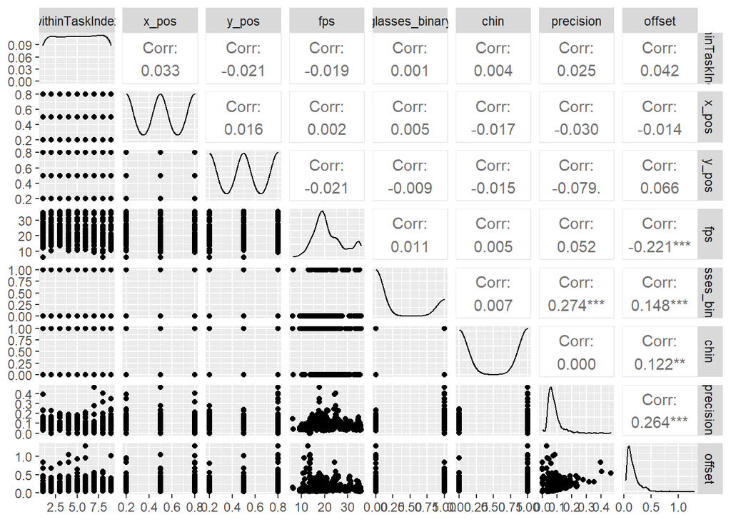

```r
predictors = c('withinTaskIndex',
               'x_pos', 'y_pos', 'fps',
               'glasses_binary', 'chin')

ggpairs(data_trial[, append(predictors, c('precision', 'offset'))],
        progress=F) # Correlations
```

# Linear model (Fixed Effects, no MLA)

Average offset=0.17 = 17%

```r
lm_null = lm(offset ~ 1, data = data_trial %>% filter(!is.na(offset)))
summary(lm_null)
```

```
##
## Call:
## lm(formula = offset ~ 1, data = data_trial %>% filter(!is.na(offset)))
##
## Residuals:
##      Min       1Q   Median       3Q      Max
## -0.14288 -0.08733 -0.04347  0.03097  1.11579
##
## Coefficients:
##             Estimate Std. Error t value            Pr(>|t|)
## (Intercept)  0.17150    0.00607   28.25 <0.0000000000000002 ***
## ---
## Signif. codes:  0 '***' 0.001 '**' 0.01 '*' 0.05 '.' 0.1 ' ' 1
##
## Residual standard error: 0.1445 on 566 degrees of freedom
```

## IO: intercept only

ICC = 0.6182. 62% of the variance can be explained by the variance between the subjects. Interdependence assumption of the simple linear regression is violated. We should to an MLA

```r
lmer0_io = lmer(
    offset ~ 1 + (1 | run_id),
    data=data_trial,
    REML=FALSE) # FML for comparing different fixed effects

summary(lmer0_io)
```

```
## Linear mixed model fit by maximum likelihood . t-tests use Satterthwaite's
##   method [lmerModLmerTest]
## Formula: offset ~ 1 + (1 | run_id)
##    Data: data_trial
##
##      AIC      BIC   logLik deviance df.resid
##   -990.9   -977.9    498.5   -996.9      564
##
## Scaled residuals:
##     Min      1Q  Median      3Q     Max
## -3.8551 -0.4664 -0.1123  0.4118  5.7505
##
## Random effects:
##  Groups   Name        Variance Std.Dev.
##  run_id   (Intercept) 0.015387 0.12405
##  Residual             0.008108 0.09004
## Number of obs: 567, groups:  run_id, 38
##
## Fixed effects:
##             Estimate Std. Error       df t value       Pr(>|t|)
## (Intercept)  0.17635    0.02067 38.10513   8.531 0.000000000227 ***
## ---
## Signif. codes:  0 '***' 0.001 '**' 0.01 '*' 0.05 '.' 0.1 ' ' 1
```

```r
ICCest(factor(data_trial$run_id), data_trial$offset, alpha=.05, CI.type="THD")
```

```
## $ICC
## [1] 0.6182631
##
## $LowerCI
## [1] 0.5079958
##
## $UpperCI
## [1] 0.7361541
##
## $N
## [1] 38
##
## $k
## [1] 14.87754
##
## $varw
## [1] 0.008112895
##
## $vara
## [1] 0.01313968
```

## RI: Random intercept

```r
data_trial = data_trial %>%
    mutate(
        y_pos_c = scale(y_pos),
        x_pos_c = scale(x_pos),
        fps_c = scale(fps))

lmer1_control = lmer(
    offset ~  withinTaskIndex + x_pos_c + y_pos_c + fps_c + (1 | run_id),
    data=data_trial,
    REML=FALSE)

summary(lmer1_control)
```

```
## Linear mixed model fit by maximum likelihood . t-tests use Satterthwaite's
##   method [lmerModLmerTest]
## Formula: offset ~ withinTaskIndex + x_pos_c + y_pos_c + fps_c + (1 | run_id)
##    Data: data_trial
##
##      AIC      BIC   logLik deviance df.resid
##   -988.0   -957.6    501.0  -1002.0      560
##
## Scaled residuals:
##     Min      1Q  Median      3Q     Max
## -3.7770 -0.4836 -0.1126  0.4346  5.6918
##
## Random effects:
##  Groups   Name        Variance Std.Dev.
##  run_id   (Intercept) 0.014634 0.12097
##  Residual             0.008059 0.08977
## Number of obs: 567, groups:  run_id, 38
##
## Fixed effects:
##                    Estimate  Std. Error          df t value       Pr(>|t|)
## (Intercept)       0.1683943   0.0216597  48.2440546   7.775 0.000000000468 ***
## withinTaskIndex   0.0009728   0.0014753 531.9979277   0.659         0.5099
## x_pos_c          -0.0001232   0.0037937 530.3382641  -0.032         0.9741
## y_pos_c           0.0068520   0.0037952 530.8226805   1.805         0.0716 .
## fps_c            -0.0148731   0.0132082 156.4189223  -1.126         0.2619
## ---
## Signif. codes:  0 '***' 0.001 '**' 0.01 '*' 0.05 '.' 0.1 ' ' 1
##
## Correlation of Fixed Effects:
##             (Intr) wthnTI x_ps_c y_ps_c
## wthnTskIndx -0.340
## x_pos_c      0.010 -0.034
## y_pos_c     -0.005  0.032 -0.016
## fps_c        0.118  0.029 -0.030  0.035
```

```r
anova(lmer0_io, lmer1_control)
```

```
## Data: data_trial
## Models:
## lmer0_io: offset ~ 1 + (1 | run_id)
## lmer1_control: offset ~ withinTaskIndex + x_pos_c + y_pos_c + fps_c + (1 | run_id)
##               npar     AIC     BIC logLik deviance  Chisq Df Pr(>Chisq)
## lmer0_io         3 -990.95 -977.92 498.47  -996.95
## lmer1_control    7 -987.97 -957.59 500.98 -1001.97 5.0231  4     0.2849
```

### Only relevant control variables

```r
lmer2_control = lmer(
    offset ~ y_pos_c + (1 | run_id),
    data=data_trial,
    REML=FALSE)

summary(lmer2_control)
```

```
## Linear mixed model fit by maximum likelihood . t-tests use Satterthwaite's
##   method [lmerModLmerTest]
## Formula: offset ~ y_pos_c + (1 | run_id)
##    Data: data_trial
##
##      AIC      BIC   logLik deviance df.resid
##   -992.3   -974.9    500.1  -1000.3      563
##
## Scaled residuals:
##     Min      1Q  Median      3Q     Max
## -3.7656 -0.4745 -0.1125  0.4234  5.6810
##
## Random effects:
##  Groups   Name        Variance Std.Dev.
##  run_id   (Intercept) 0.015347 0.12388
##  Residual             0.008059 0.08977
## Number of obs: 567, groups:  run_id, 38
##
## Fixed effects:
##               Estimate Std. Error         df t value       Pr(>|t|)
## (Intercept)   0.176403   0.020642  38.114621   8.546 0.000000000217 ***
## y_pos_c       0.006911   0.003791 530.785101   1.823         0.0688 .
## ---
## Signif. codes:  0 '***' 0.001 '**' 0.01 '*' 0.05 '.' 0.1 ' ' 1
##
## Correlation of Fixed Effects:
##         (Intr)
## y_pos_c 0.002
```

```r
anova(lmer0_io, lmer2_control)
```

```
## Data: data_trial
## Models:
## lmer0_io: offset ~ 1 + (1 | run_id)
## lmer2_control: offset ~ y_pos_c + (1 | run_id)
##               npar     AIC     BIC logLik deviance  Chisq Df Pr(>Chisq)
## lmer0_io         3 -990.95 -977.92 498.47  -996.95
## lmer2_control    4 -992.26 -974.90 500.13 -1000.26 3.3143  1    0.06868 .
## ---
## Signif. codes:  0 '***' 0.001 '**' 0.01 '*' 0.05 '.' 0.1 ' ' 1
```

### adding chin rest

Look at the predictor correlation

```r
lmer3_experimental = lmer(
    offset ~ y_pos_c + glasses_binary + chin + (1 | run_id),
    data=data_trial,
    REML=FALSE)
summary(lmer3_experimental)
```

```
## Linear mixed model fit by maximum likelihood . t-tests use Satterthwaite's
##   method [lmerModLmerTest]
## Formula: offset ~ y_pos_c + glasses_binary + chin + (1 | run_id)
##    Data: data_trial
##
##      AIC      BIC   logLik deviance df.resid
##   -998.2   -972.2    505.1  -1010.2      561
##
## Scaled residuals:
##     Min      1Q  Median      3Q     Max
## -3.9337 -0.4944 -0.0998  0.4045  5.6622
##
## Random effects:
##  Groups   Name        Variance Std.Dev.
##  run_id   (Intercept) 0.014844 0.12184
##  Residual             0.007927 0.08903
## Number of obs: 567, groups:  run_id, 38
##
## Fixed effects:
##                  Estimate Std. Error         df t value   Pr(>|t|)
## (Intercept)      0.153949   0.024341  39.701013   6.325 0.00000017 ***
## y_pos_c          0.007171   0.003761 530.683867   1.907    0.05708 .
## glasses_binary   0.037777   0.044971  38.511440   0.840    0.40608
## chin             0.023066   0.007535 531.004297   3.061    0.00232 **
## ---
## Signif. codes:  0 '***' 0.001 '**' 0.01 '*' 0.05 '.' 0.1 ' ' 1
##
## Correlation of Fixed Effects:
##             (Intr) y_ps_c glsss_
## y_pos_c     -0.007
## glasss_bnry -0.529  0.011
## chin        -0.161  0.020  0.007
```

```r
anova(lmer2_control, lmer3_experimental)
```

```
## Data: data_trial
## Models:
## lmer2_control: offset ~ y_pos_c + (1 | run_id)
## lmer3_experimental: offset ~ y_pos_c + glasses_binary + chin + (1 | run_id)
##                    npar     AIC     BIC logLik deviance  Chisq Df Pr(>Chisq)
## lmer2_control         4 -992.26 -974.90 500.13  -1000.3
## lmer3_experimental    6 -998.21 -972.16 505.10  -1010.2 9.9471  2   0.006919 **
## ---
## Signif. codes:  0 '***' 0.001 '**' 0.01 '*' 0.05 '.' 0.1 ' ' 1
```

### Only relevant variables

```r
lmer4_experimental = lmer(
    offset ~ y_pos_c + chin + (1 | run_id),
    data=data_trial,
    REML=FALSE)

summary(lmer4_experimental)
```

```
## Linear mixed model fit by maximum likelihood . t-tests use Satterthwaite's
##   method [lmerModLmerTest]
## Formula: offset ~ y_pos_c + chin + (1 | run_id)
##    Data: data_trial
##
##      AIC      BIC   logLik deviance df.resid
##   -999.5   -977.8    504.8  -1009.5      562
##
## Scaled residuals:
##     Min      1Q  Median      3Q     Max
## -3.9231 -0.4946 -0.1040  0.4040  5.6512
##
## Random effects:
##  Groups   Name        Variance Std.Dev.
##  run_id   (Intercept) 0.015152 0.12309
##  Residual             0.007926 0.08903
## Number of obs: 567, groups:  run_id, 38
##
## Fixed effects:
##               Estimate Std. Error         df t value      Pr(>|t|)
## (Intercept)   0.164757   0.020860  40.789715   7.898 0.00000000095 ***
## y_pos_c       0.007135   0.003760 530.806415   1.897       0.05831 .
## chin          0.023008   0.007535 531.072449   3.054       0.00237 **
## ---
## Signif. codes:  0 '***' 0.001 '**' 0.01 '*' 0.05 '.' 0.1 ' ' 1
##
## Correlation of Fixed Effects:
##         (Intr) y_ps_c
## y_pos_c -0.002
## chin    -0.183  0.020
```

### Interaction

The effect depends on the y position

```r
lmer5_interaction = lmer(
    offset ~ y_pos_c * chin + (1 | run_id),
    data=data_trial,
    REML=FALSE)

summary(lmer5_interaction)
```

```
## Linear mixed model fit by maximum likelihood . t-tests use Satterthwaite's
##   method [lmerModLmerTest]
## Formula: offset ~ y_pos_c * chin + (1 | run_id)
##    Data: data_trial
##
##      AIC      BIC   logLik deviance df.resid
##  -1009.8   -983.7    510.9  -1021.8      561
##
## Scaled residuals:
##     Min      1Q  Median      3Q     Max
## -3.7765 -0.5037 -0.1072  0.3935  5.5477
##
## Random effects:
##  Groups   Name        Variance Std.Dev.
##  run_id   (Intercept) 0.015097 0.12287
##  Residual             0.007747 0.08802
## Number of obs: 567, groups:  run_id, 38
##
## Fixed effects:
##                Estimate Std. Error         df t value       Pr(>|t|)
## (Intercept)    0.164853   0.020807  40.733771   7.923 0.000000000886 ***
## y_pos_c       -0.006218   0.005311 531.902814  -1.171       0.242218
## chin           0.023054   0.007449 531.036801   3.095       0.002073 **
## y_pos_c:chin   0.026206   0.007444 530.885126   3.520       0.000468 ***
## ---
## Signif. codes:  0 '***' 0.001 '**' 0.01 '*' 0.05 '.' 0.1 ' ' 1
##
## Correlation of Fixed Effects:
##             (Intr) y_ps_c chin
## y_pos_c     -0.002
## chin        -0.181  0.012
## y_pos_c:chn  0.001 -0.714  0.002
```

```r
anova(lmer4_experimental, lmer5_interaction)
```

```
## Data: data_trial
## Models:
## lmer4_experimental: offset ~ y_pos_c + chin + (1 | run_id)
## lmer5_interaction: offset ~ y_pos_c * chin + (1 | run_id)
##                    npar      AIC     BIC logLik deviance  Chisq Df Pr(>Chisq)
## lmer4_experimental    5  -999.51 -977.81 504.75  -1009.5
## lmer5_interaction     6 -1009.76 -983.72 510.88  -1021.8 12.254  1  0.0004643
##
## lmer4_experimental
## lmer5_interaction  ***
## ---
## Signif. codes:  0 '***' 0.001 '**' 0.01 '*' 0.05 '.' 0.1 ' ' 1
```

## Random slopes for chin

### Basic

```r
lmer6_rs = lmer(
    offset ~ y_pos_c + chin + (chin | run_id),
    data=data_trial,
    REML=FALSE)
summary(lmer6_rs)
```

```
## Linear mixed model fit by maximum likelihood . t-tests use Satterthwaite's
##   method [lmerModLmerTest]
## Formula: offset ~ y_pos_c + chin + (chin | run_id)
##    Data: data_trial
##
##      AIC      BIC   logLik deviance df.resid
##  -1013.1   -982.7    513.6  -1027.1      560
##
## Scaled residuals:
##     Min      1Q  Median      3Q     Max
## -4.5622 -0.4641 -0.0992  0.3981  5.3008
##
## Random effects:
##  Groups   Name        Variance Std.Dev. Corr
##  run_id   (Intercept) 0.010292 0.10145
##           chin        0.001868 0.04322  0.74
##  Residual             0.007556 0.08693
## Number of obs: 567, groups:  run_id, 38
##
## Fixed effects:
##               Estimate Std. Error         df t value        Pr(>|t|)
## (Intercept)   0.162525   0.017434  34.437636   9.322 0.0000000000603 ***
## y_pos_c       0.006957   0.003673 504.217117   1.894          0.0588 .
## chin          0.025063   0.010295  33.018377   2.434          0.0205 *
## ---
## Signif. codes:  0 '***' 0.001 '**' 0.01 '*' 0.05 '.' 0.1 ' ' 1
##
## Correlation of Fixed Effects:
##         (Intr) y_ps_c
## y_pos_c -0.002
## chin     0.328  0.017
```

```r
# ranef(lmer6_rs)
anova(lmer4_experimental, lmer6_rs)
```

```
## Data: data_trial
## Models:
## lmer4_experimental: offset ~ y_pos_c + chin + (1 | run_id)
## lmer6_rs: offset ~ y_pos_c + chin + (chin | run_id)
##                    npar      AIC     BIC logLik deviance  Chisq Df Pr(>Chisq)
## lmer4_experimental    5  -999.51 -977.81 504.75  -1009.5
## lmer6_rs              7 -1013.12 -982.74 513.56  -1027.1 17.613  2  0.0001498
##
## lmer4_experimental
## lmer6_rs           ***
## ---
## Signif. codes:  0 '***' 0.001 '**' 0.01 '*' 0.05 '.' 0.1 ' ' 1
```

### Intercepts as outcomes

Offset differences are predicted by fps. L2 predictor fps is centered by an unweighted mean. No evidence for an effect of subject’s computation power on the offset.

```r
# Get average
grouped = data_trial %>%
    group_by(run_id) %>%
    summarise(fps_subject = mean(fps))
data_trial = data_trial %>%
    merge_by_subject(grouped, 'fps_subject') %>%
    mutate(fps_subject_c = fps - mean(grouped$fps_subject))

lmer7_iao = lmer(
    offset ~ y_pos_c + chin + fps_subject_c + (chin | run_id),
    data=data_trial,
    REML=FALSE)
summary(lmer7_iao)
```

```
## Linear mixed model fit by maximum likelihood . t-tests use Satterthwaite's
##   method [lmerModLmerTest]
## Formula: offset ~ y_pos_c + chin + fps_subject_c + (chin | run_id)
##    Data: data_trial
##
##      AIC      BIC   logLik deviance df.resid
##  -1011.5   -976.8    513.7  -1027.5      559
##
## Scaled residuals:
##     Min      1Q  Median      3Q     Max
## -4.5535 -0.4723 -0.1025  0.3950  5.2961
##
## Random effects:
##  Groups   Name        Variance Std.Dev. Corr
##  run_id   (Intercept) 0.010066 0.10033
##           chin        0.001824 0.04271  0.72
##  Residual             0.007561 0.08696
## Number of obs: 567, groups:  run_id, 38
##
## Fixed effects:
##                 Estimate Std. Error         df t value       Pr(>|t|)
## (Intercept)     0.162999   0.017279  34.265782   9.434 0.000000000047 ***
## y_pos_c         0.006867   0.003678 504.710972   1.867         0.0625 .
## chin            0.024969   0.010243  32.489370   2.438         0.0204 *
## fps_subject_c  -0.001221   0.001948  97.906345  -0.627         0.5324
## ---
## Signif. codes:  0 '***' 0.001 '**' 0.01 '*' 0.05 '.' 0.1 ' ' 1
##
## Correlation of Fixed Effects:
##             (Intr) y_ps_c chin
## y_pos_c     -0.004
## chin         0.310  0.018
## fps_sbjct_c -0.042  0.041  0.015
```

```r
# ranef(lmer7_iao)
anova(lmer6_rs, lmer7_iao)
```

```
## Data: data_trial
## Models:
## lmer6_rs: offset ~ y_pos_c + chin + (chin | run_id)
## lmer7_iao: offset ~ y_pos_c + chin + fps_subject_c + (chin | run_id)
##           npar     AIC     BIC logLik deviance  Chisq Df Pr(>Chisq)
## lmer6_rs     7 -1013.1 -982.74 513.56  -1027.1
## lmer7_iao    8 -1011.5 -976.77 513.75  -1027.5 0.3748  1     0.5404
```

## Cross-level interaction

Can the effect of the chin-rest be explained by differences in fps?

```r
lmer8_cli = lmer(
    offset ~ y_pos_c + chin * fps_subject_c + (chin | run_id),
    data=data_trial,
    REML=FALSE)
summary(lmer8_cli)
```

```
## Linear mixed model fit by maximum likelihood . t-tests use Satterthwaite's
##   method [lmerModLmerTest]
## Formula: offset ~ y_pos_c + chin * fps_subject_c + (chin | run_id)
##    Data: data_trial
##
##      AIC      BIC   logLik deviance df.resid
##  -1013.3   -974.2    515.6  -1031.3      558
##
## Scaled residuals:
##     Min      1Q  Median      3Q     Max
## -4.5791 -0.4821 -0.1081  0.4040  5.3557
##
## Random effects:
##  Groups   Name        Variance Std.Dev. Corr
##  run_id   (Intercept) 0.010125 0.10062
##           chin        0.001385 0.03722  0.75
##  Residual             0.007559 0.08694
## Number of obs: 567, groups:  run_id, 38
##
## Fixed effects:
##                      Estimate Std. Error         df t value        Pr(>|t|)
## (Intercept)          0.161365   0.017346  34.196108   9.303 0.0000000000679 ***
## y_pos_c              0.007013   0.003677 504.553292   1.907          0.0570 .
## chin                 0.029210   0.009865  34.741428   2.961          0.0055 **
## fps_subject_c       -0.001272   0.001943  99.653494  -0.655          0.5141
## chin:fps_subject_c  -0.002726   0.001353  38.890656  -2.014          0.0510 .
## ---
## Signif. codes:  0 '***' 0.001 '**' 0.01 '*' 0.05 '.' 0.1 ' ' 1
##
## Correlation of Fixed Effects:
##             (Intr) y_ps_c chin   fps_s_
## y_pos_c     -0.005
## chin         0.269  0.021
## fps_sbjct_c -0.040  0.040  0.010
## chn:fps_sb_  0.053 -0.017 -0.219 -0.005
```

```r
anova(lmer7_iao, lmer8_cli)
```

```
## Data: data_trial
## Models:
## lmer7_iao: offset ~ y_pos_c + chin + fps_subject_c + (chin | run_id)
## lmer8_cli: offset ~ y_pos_c + chin * fps_subject_c + (chin | run_id)
##           npar     AIC     BIC logLik deviance  Chisq Df Pr(>Chisq)
## lmer7_iao    8 -1011.5 -976.77 513.75  -1027.5
## lmer8_cli    9 -1013.3 -974.23 515.65  -1031.3 3.7964  1    0.05136 .
## ---
## Signif. codes:  0 '***' 0.001 '**' 0.01 '*' 0.05 '.' 0.1 ' ' 1
```

# Effects

Use formulas without random slopes (Snijders & Bosker, 2012)

```r
m0 <- lmer(offset ~ y_pos_c + (1 | run_id),
           data=data_trial,
           REML=FALSE)
m1 <- lmer(offset ~ y_pos_c + chin + (1 | run_id),
           data=data_trial,
           REML=FALSE)

L1_m0 <- sigma(m0)^2 # L1-Residualvarianz RIO Modell
L1_m1 <- sigma(m1)^2 # L1-Residualvarianz RI Modell
print('Pseudo R^2')
```

```
## [1] "Pseudo R^2"
```

```r
print(paste(
    'Reduction of L1 variance due to chin: ',
    (L1_m0 - L1_m1)/L1_m0
))
```

```
## [1] "Reduction of L1 variance due to chin:  0.0164172222330947"
```

```r
L2_m0 <- unlist(summary(m0)$var) # Interceptvarianz RI Modell
L2_m1 <- unlist(summary(m1)$var) # Interceptvarianz IAO Modell
print(paste(
    'Reduction of L2 variance due to chin: ',
    (L2_m0 - L2_m1)/L2_m0
))
```

```
## [1] "Reduction of L2 variance due to chin:  0.0126683360265789"
```

# Assumptions

Sources: - https://www.youtube.com/watch?v=UvyxSqEXBwc - https://www.pythonfordatascience.org/mixed-effects-regression-python/ - https://ademos.people.uic.edu/Chapter18.html

## Linearity: Plot residuals vs. observed

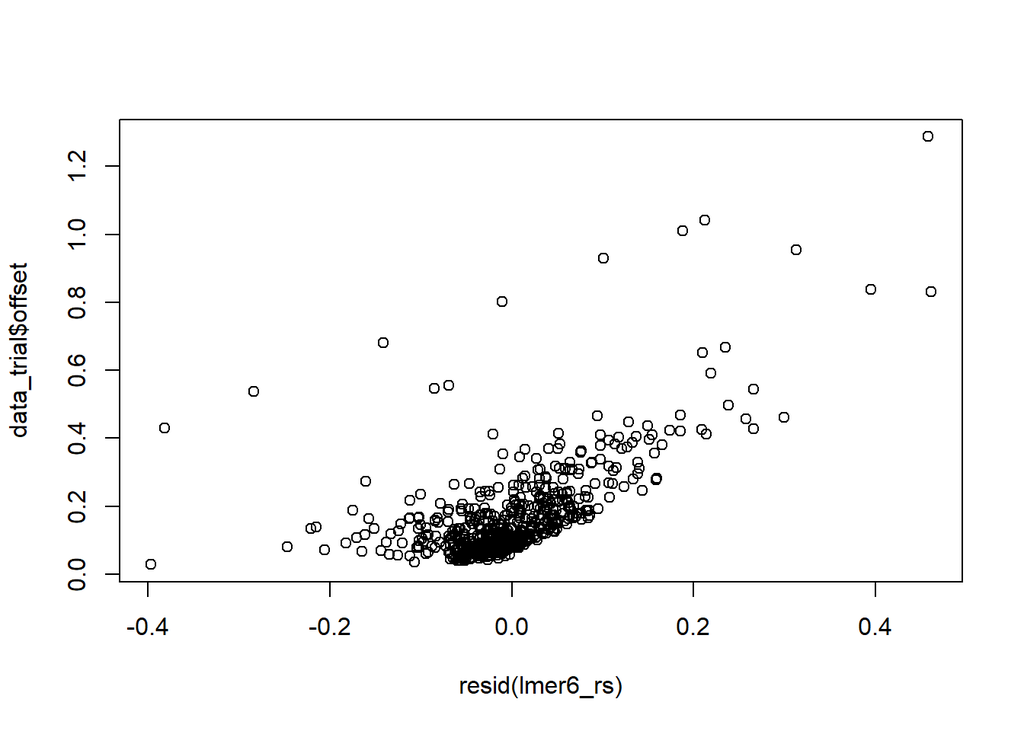

```r
plot(resid(lmer6_rs), data_trial$offset)
```

## Homosedasticity: Homogeneity of residuals across groups

ANOVA as a variation of Levene’s test. Extract residuals from the model and square the absolute value. Should be not significant. Significant differences across residuals. We have Heteroscedasticity.

```r
data_trial = data_trial %>%
    mutate(
        res = residuals(lmer6_rs),
        res_sq = (abs(res)^2))

levene_model <- lm(res_sq ~ run_id, data=data_trial)
anova(levene_model)
```

```
## Analysis of Variance Table
##
## Response: res_sq
##            Df   Sum Sq   Mean Sq F value    Pr(>F)
## run_id      1 0.005461 0.0054613  14.066 0.0001947 ***
## Residuals 565 0.219361 0.0003883
## ---
## Signif. codes:  0 '***' 0.001 '**' 0.01 '*' 0.05 '.' 0.1 ' ' 1
```

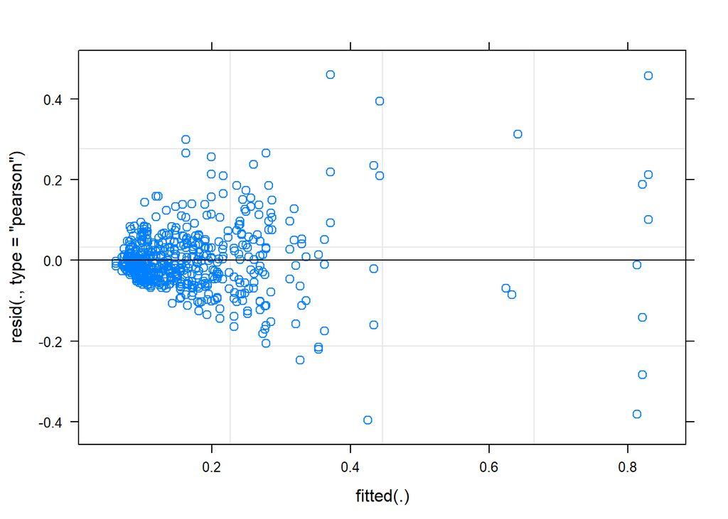

```r
plot(lmer6_rs)
```

## Normal distribution of residuals

Normal distribution not given.

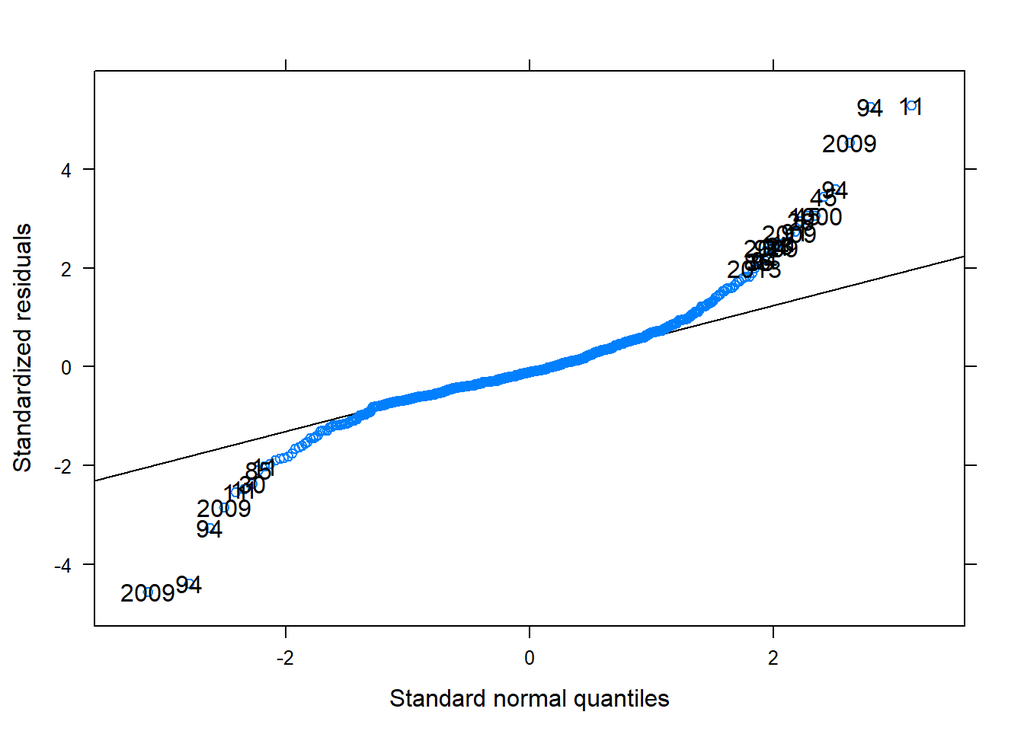

```r
qqmath(lmer6_rs, id=0.05)
```

Lets try with log transformed offset Does not make it any better

```r
data_trial = data_trial %>%
    mutate(
        offset_log = log(offset+1),
        offset_log10 = log10(offset+1),
        offset_sqrt = sqrt(offset),
        )

lmer_log = lmer(
    offset_log ~ y_pos_c + chin + (chin | run_id),
    data=data_trial,
    REML=FALSE)
summary(lmer_log)
```

```
## Linear mixed model fit by maximum likelihood . t-tests use Satterthwaite's
##   method [lmerModLmerTest]
## Formula: offset_log ~ y_pos_c + chin + (chin | run_id)
##    Data: data_trial
##
##      AIC      BIC   logLik deviance df.resid
##  -1329.5  -1299.1    671.8  -1343.5      560
##
## Scaled residuals:
##     Min      1Q  Median      3Q     Max
## -4.7239 -0.5132 -0.1030  0.4726  4.6025
##
## Random effects:
##  Groups   Name        Variance  Std.Dev. Corr
##  run_id   (Intercept) 0.0060047 0.07749
##           chin        0.0009553 0.03091  0.54
##  Residual             0.0043110 0.06566
## Number of obs: 567, groups:  run_id, 38
##
## Fixed effects:
##               Estimate Std. Error         df t value          Pr(>|t|)
## (Intercept)   0.145529   0.013314  35.076640  10.931 0.000000000000763 ***
## y_pos_c       0.003887   0.002776 504.011481   1.400            0.1620
## chin          0.018066   0.007606  34.692958   2.375            0.0232 *
## ---
## Signif. codes:  0 '***' 0.001 '**' 0.01 '*' 0.05 '.' 0.1 ' ' 1
##
## Correlation of Fixed Effects:
##         (Intr) y_ps_c
## y_pos_c -0.003
## chin     0.182  0.018
```

```r
ranef(lmer_log)
```

```
## $run_id
##        (Intercept)          chin
## 5    -0.0667870679 -0.0292436019
## 6    -0.0349563672 -0.0041745491
## 7    -0.0598931176 -0.0176187825
## 11    0.0908515247  0.0439832645
## 13   -0.0169378178 -0.0075046893
## 19   -0.0147988769 -0.0060249495
## 24   -0.0524951533  0.0128680835
## 25   -0.0575935599 -0.0007960199
## 28    0.0471401528 -0.0328749160
## 30    0.0773835994 -0.0030613103
## 32   -0.0391555511 -0.0279044565
## 36    0.0186935242  0.0339044907
## 37   -0.0003692991 -0.0079432162
```

[output cut: 27 more lines]

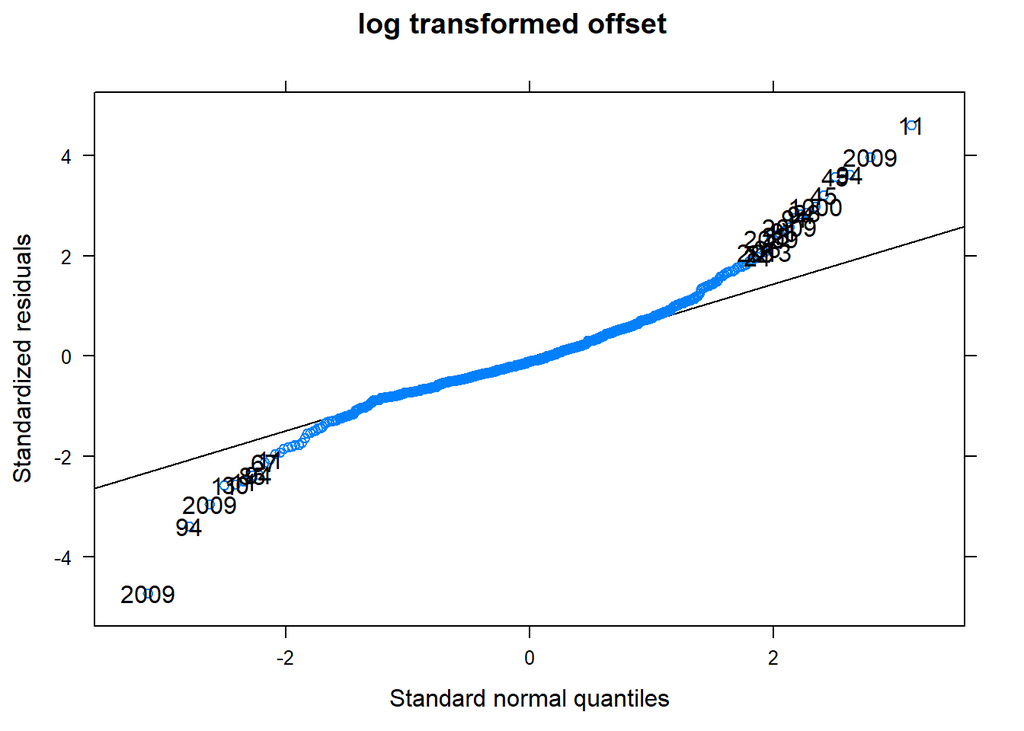

```r
qqmath(lmer_log, id=0.05, prep_global_data='log transformed offset')
```

```r
lmer_log10 = lmer(
    offset_log10 ~ y_pos_c + chin + (chin | run_id),
    data=data_trial,
    REML=FALSE)
summary(lmer_log10)
```

```
## Linear mixed model fit by maximum likelihood . t-tests use Satterthwaite's
##   method [lmerModLmerTest]
## Formula: offset_log10 ~ y_pos_c + chin + (chin | run_id)
##    Data: data_trial
##
##      AIC      BIC   logLik deviance df.resid
##  -2275.3  -2244.9   1144.7  -2289.3      560
##
## Scaled residuals:
##     Min      1Q  Median      3Q     Max
## -4.7239 -0.5132 -0.1030  0.4726  4.6025
##
## Random effects:
##  Groups   Name        Variance  Std.Dev. Corr
##  run_id   (Intercept) 0.0011326 0.03365
##           chin        0.0001802 0.01342  0.54
##  Residual             0.0008131 0.02852
## Number of obs: 567, groups:  run_id, 38
##
## Fixed effects:
##               Estimate Std. Error         df t value          Pr(>|t|)
## (Intercept)   0.063203   0.005782  35.076640  10.931 0.000000000000763 ***
## y_pos_c       0.001688   0.001205 504.011481   1.400            0.1620
## chin          0.007846   0.003303  34.692958   2.375            0.0232 *
## ---
## Signif. codes:  0 '***' 0.001 '**' 0.01 '*' 0.05 '.' 0.1 ' ' 1
##
## Correlation of Fixed Effects:
##         (Intr) y_ps_c
## y_pos_c -0.003
## chin     0.182  0.018
```

```r
ranef(lmer_log10)
```

```
## $run_id
##        (Intercept)          chin
## 5    -0.0290052550 -0.0127003349
## 6    -0.0151813574 -0.0018129837
## 7    -0.0260112505 -0.0076517400
## 11    0.0394563159  0.0191016891
## 13   -0.0073560008 -0.0032592451
## 19   -0.0064270706 -0.0026166023
## 24   -0.0227983554  0.0055885377
## 25   -0.0250125652 -0.0003457070
## 28    0.0204727082 -0.0142773946
## 30    0.0336072702 -0.0013295102
## 32   -0.0170050398 -0.0121187515
## 36    0.0081184944  0.0147245332
## 37   -0.0001603846 -0.0034496950
```

[output cut: 27 more lines]

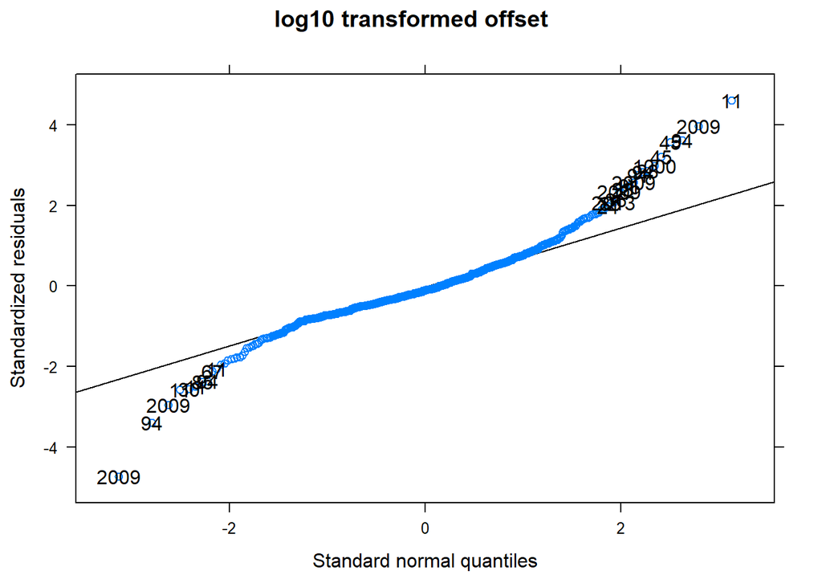

```r
qqmath(lmer_log10, id=0.05, prep_global_data='log10 transformed offset')
```

```r
lmer_sqrt = lmer(
    offset_sqrt ~ y_pos_c + chin + (chin | run_id),
    data=data_trial,
    REML=FALSE)
summary(lmer_sqrt)
```

```
## Linear mixed model fit by maximum likelihood . t-tests use Satterthwaite's
##   method [lmerModLmerTest]
## Formula: offset_sqrt ~ y_pos_c + chin + (chin | run_id)
##    Data: data_trial
##
##      AIC      BIC   logLik deviance df.resid
##   -997.2   -966.8    505.6  -1011.2      560
##
## Scaled residuals:
##     Min      1Q  Median      3Q     Max
## -5.0176 -0.5711 -0.0865  0.5855  3.7621
##
## Random effects:
##  Groups   Name        Variance Std.Dev. Corr
##  run_id   (Intercept) 0.010503 0.10248
##           chin        0.001605 0.04006  0.32
##  Residual             0.007758 0.08808
## Number of obs: 567, groups:  run_id, 38
##
## Fixed effects:
##               Estimate Std. Error         df t value            Pr(>|t|)
## (Intercept)   0.381735   0.017647  35.668032  21.631 <0.0000000000000002 ***
## y_pos_c       0.003021   0.003725 504.218930   0.811              0.4177
## chin          0.022458   0.010074  36.038440   2.229              0.0321 *
## ---
## Signif. codes:  0 '***' 0.001 '**' 0.01 '*' 0.05 '.' 0.1 ' ' 1
##
## Correlation of Fixed Effects:
##         (Intr) y_ps_c
## y_pos_c -0.003
## chin     0.031  0.018
```

```r
ranef(lmer_sqrt)
```

```
## $run_id
##       (Intercept)          chin
## 5    -0.097961358 -0.0452917323
## 6    -0.048914970 -0.0034123865
## 7    -0.087342963 -0.0194817742
## 11    0.123154110  0.0496929910
## 13   -0.013294595 -0.0082832928
## 19   -0.011292898 -0.0048641798
## 24   -0.082037801  0.0349724289
## 25   -0.087899721  0.0088585620
## 28    0.077346037 -0.0528909173
## 30    0.114934516 -0.0127734313
## 32   -0.051126267 -0.0408513627
## 36    0.030630428  0.0498045854
## 37    0.008225735 -0.0090136483
```

[output cut: 27 more lines]

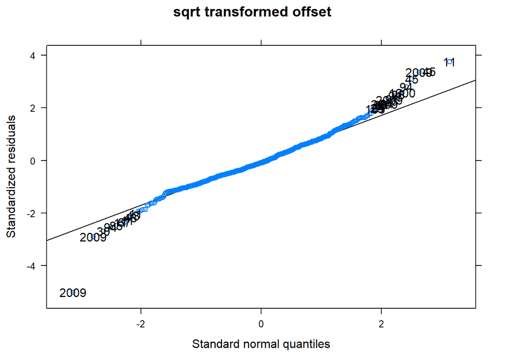

```r
qqmath(lmer_sqrt, id=0.05, prep_global_data='sqrt transformed offset')
```

### Residuals for sqrt transformation

Does not look better

```r
data_trial = data_trial %>%
    mutate(
        res = residuals(lmer_sqrt),
        res_sq = (abs(res)^2))

levene_model <- lm(res_sq ~ run_id, data=data_trial)
anova(levene_model)
```

```
## Analysis of Variance Table
##
## Response: res_sq
##            Df   Sum Sq   Mean Sq F value      Pr(>F)
## run_id      1 0.004033 0.0040327  20.317 0.000007982 ***
## Residuals 565 0.112150 0.0001985
## ---
## Signif. codes:  0 '***' 0.001 '**' 0.01 '*' 0.05 '.' 0.1 ' ' 1
```

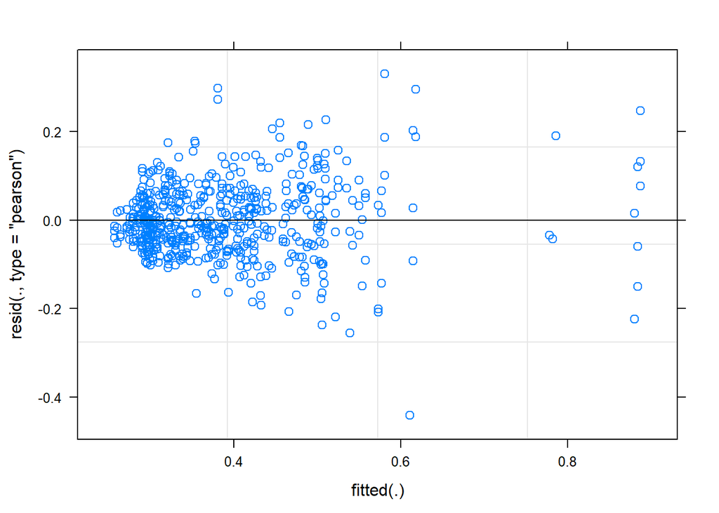

```r
plot(lmer_sqrt)
```

## Multicollinearity of the predictors

No multicollinearity

```r
correlation = cor(
    data_trial %>%
        select(predictors),
    use = 'pairwise.complete.obs'
)
```

```
## Note: Using an external vector in selections is ambiguous.
## i Use `all_of(predictors)` instead of `predictors` to silence this message.
## i See <https://tidyselect.r-lib.org/reference/faq-external-vector.html>.
```

```r
symnum(correlation)
```

```
##                 w x y f g c
## withinTaskIndex 1
## x_pos             1
## y_pos               1
## fps                   1
## glasses_binary          1
## chin                      1
## attr(,"legend")
## [1] 0 ' ' 0.3 '.' 0.6 ',' 0.8 '+' 0.9 '*' 0.95 'B' 1
```

```r
correlation
```

```
##                 withinTaskIndex        x_pos        y_pos          fps
## withinTaskIndex     1.000000000  0.033454906 -0.020917506 -0.019120166
## x_pos               0.033454906  1.000000000  0.015852393  0.002353003
## y_pos              -0.020917506  0.015852393  1.000000000 -0.021489471
## fps                -0.019120166  0.002353003 -0.021489471  1.000000000
## glasses_binary      0.001417774  0.004918218 -0.008758127  0.011473275
## chin                0.004011161 -0.017282528 -0.015205304  0.005080381
##                 glasses_binary         chin
## withinTaskIndex    0.001417774  0.004011161
## x_pos              0.004918218 -0.017282528
## y_pos             -0.008758127 -0.015205304
## fps                0.011473275  0.005080381
## glasses_binary     1.000000000  0.006629941
## chin               0.006629941  1.000000000
```

```r
car::vif(lmer6_rs)
```

```
##  y_pos_c     chin
## 1.000294 1.000294
```

## HLMdiag

https://cran.rstudio.com/web/packages/HLMdiag/index.html

```r
#case_delete() #iteratively delete groups corresponding to the levels of a hierarchical linear model, using lmer to fit the models for each deleted case

#covratio() #calculate measures of the change in the covariance matrices for the fixed effects based on the deletion of an observation, or group of observations,

#diagnostics() #is used to compute deletion diagnostics for a hierarchical linear model based on the building blocks returned by case_delete.

#HLMresid() #extracts residuals from a hierarchical linear model fit using lmer. Can provide a variety of different types of residuals based upon the specifications when you call the function

#leverage() #calculates the leverage of a hierarchical linear model fit

#mdffits() #calculate measures of the change in the fixed effects estimates based on the deletetion of an observation, or group of observations
```